# Titanic

## IMPORT DEI DATI

Per prima cosa procediamo con:

- Importazione dei dati
- Trasformazione dei dati non categoriali ma che dovrebbero esserlo in dati categoriali
- Creo nuova variabile titanic che racchiude il dataset titanic_train per non riscrivere ogni volta _train

```r
library(titanic) #la prima volta eseguire install.packages("titanic") se non lo avete già installato
factors <- c('Survived', 'Pclass', 'Sex', 'Cabin', 'Embarked')
titanic_train[factors] <- lapply(titanic_train[factors], function(x) as.factor(x))
titanic <- titanic_train
```

### REMIND sul dataset

Per osservare il vostro dataset potete utilizzare la funzione `View(titanic)` oppure `glimpse(titanic)` e per cercare aiuto su cosa rappresentano le variabili potete usare l’help scrivendo nella console `?titanic_train`.

Il dataset si dice che è “tidy” quando ad ogni riga corrisponde un’osservazione (in questo caso ognugno degli 891 passeggeri ha una riga nel dataset) e in ogni colonna viene rappresentata una variabile (per ogni passeggero troviamo 12 colonne che descrivono vari aspetti, dal nome al sesso alla classe).

Il dataset `titanic` è già “tidy”, le esplorazioni saranno più facili.

### Esercizio 1

Quale colonna contiene l’informazione sulla classe d’imbarco di ogni passeggero?

Come posso usare questa informazione per sapere quanti passeggeri ci sono in ogni classe?

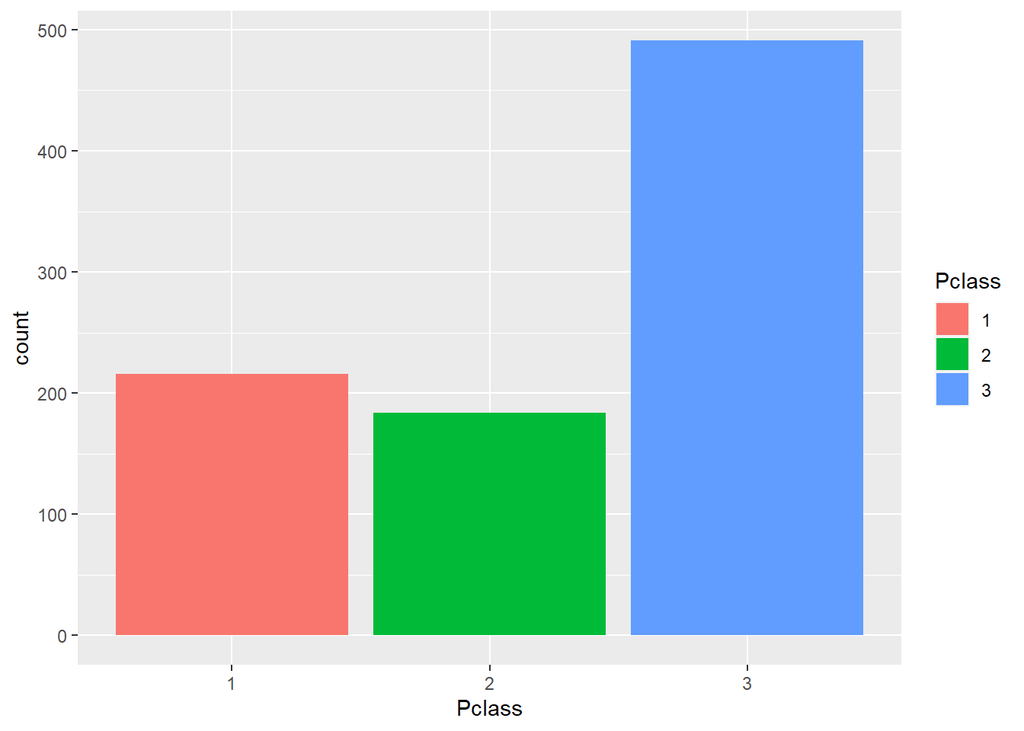

```r
ggplot(titanic, aes(x = Pclass,
                    fill = Pclass) ) +
  geom_bar()
```

```r
# se voglio vedere proporzione posso aggiungere nelle estetiche anche
# y= after_stat(prop), group = 1
```

Suggerimento: Quale `geom_function` si utilizza per creare un grafico a barre?

Spazio per la tua analisi del grafico:

- usa i trattini per costruire
- un elenco puntato

### Esercizio 2

Quale variabile contiene le informazioni sul genere dei passeggeri?

Ci sono più uomini o donne per ciascuna classe?

Come varia la loro proporzione tra le varie classi?

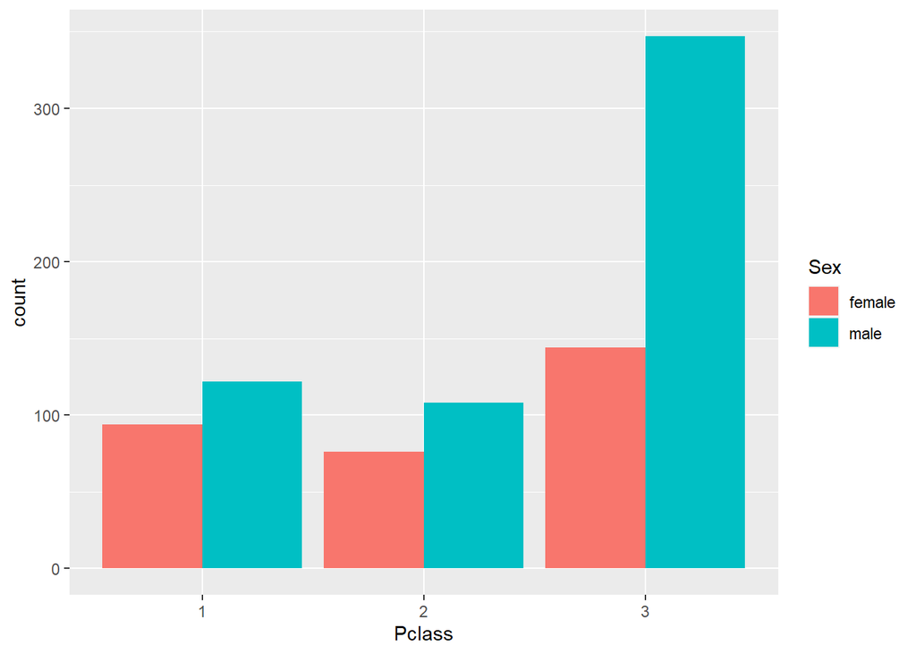

```r
ggplot(titanic, aes( x = Pclass,
                     fill = Sex) ) +
  geom_bar(position = "dodge")
```

Suggerimento: Quale argomento vi permette di colorare/riempire i grafici a barre?

Quale `position = " "` vi facilita il confronto?

Spazio per la tua analisi del grafico:

### Esercizio 3

Quale variabile contiene le infromazioni sulla sopravvivenza al naufragio?

Vi sono differenze di sopravvivenza al variare della classe?

Ipotizza il risultato che ti aspetti prima di creare il grafico, poi esplora la tua ipotesi tramite un `ggplot`.

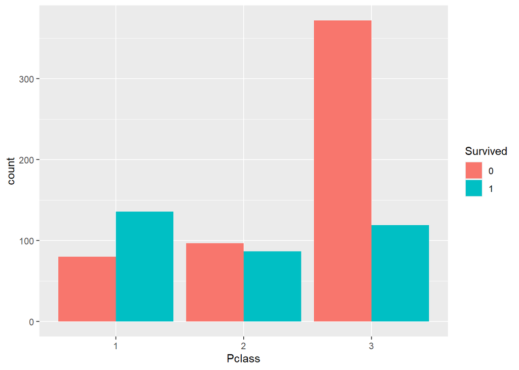

```r
ggplot(titanic, aes(x= Pclass,
                    fill = Survived)) +
  geom_bar(position = "dodge")
```

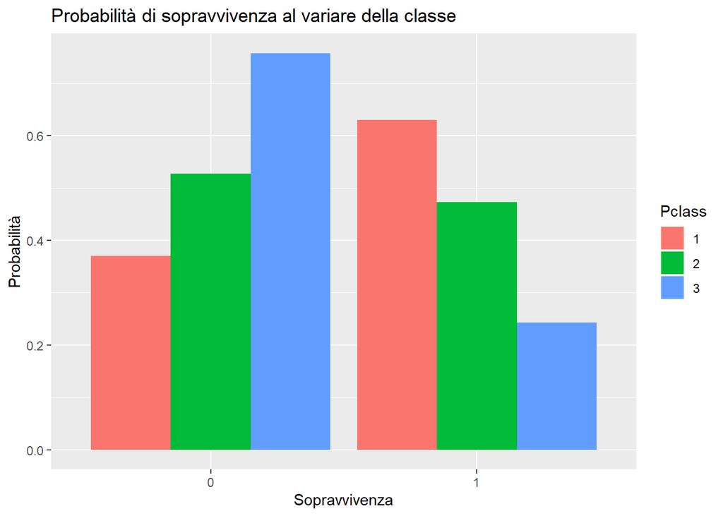

```r
#oppure
ggplot(titanic, aes(x = Survived,
                    fill = Pclass,
                    y = after_stat(prop),
                    group = Pclass)) +
  geom_bar(position = "dodge") +
  labs(title = "Probabilità di sopravvivenza al variare della classe",
       x = "Sopravvivenza",
       y= "Probabilità")
```

Come ti spieghi il risultato della tua analisi?

Spazio per la tua analisi del grafico:

### Esercizio 4

Una donna aveva più probabilità di sopravvivere?

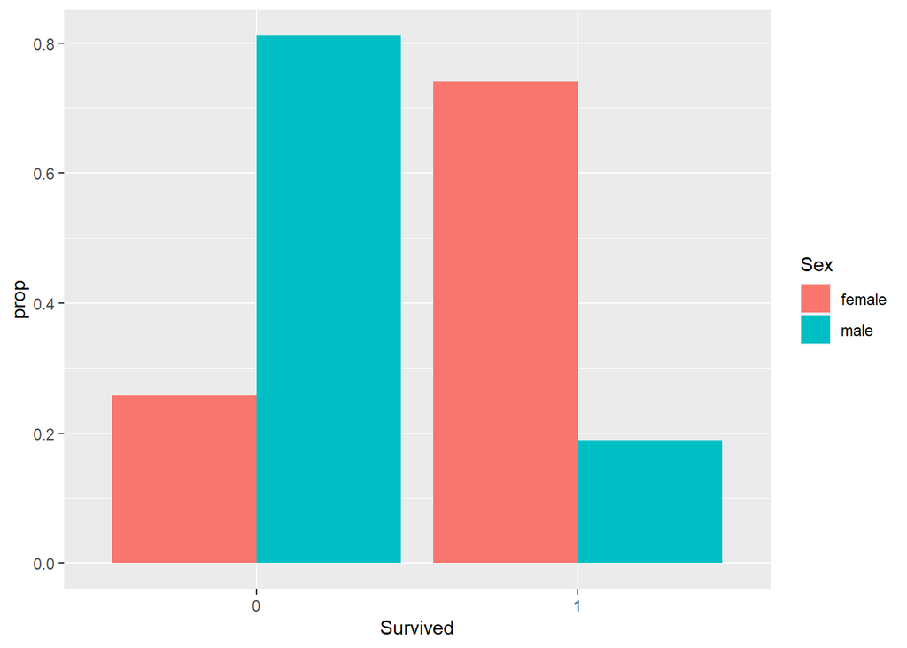

```r
ggplot(titanic, aes(x = Survived,
                    fill = Sex,
                    y= after_stat(prop),
                    group = Sex)) +
  geom_bar(position = "dodge")
```

Come te lo spieghi? La strategia del “prima le donne e i bambini” sembra aver funzionato?

Spazio per la tua analisi del grafico:

### Esercizio 5

Una delle ipotesi che si possono fare è che la differenza nella sopravvivenza sia legata più alla maggior presenza femminile nelle classi d’imbarco più lussuose, che abbiamo visto avere una sopravvivenza maggiore.

Ti sembra un’ipotesi sensata? Per esplorare più a fondo questa intuizione prova a rispondere con un grafico a questa domanda:

Una donna aveva più probabilità di sopravvivere rispetto agli uomini della sua stessa classe d’imbarco?

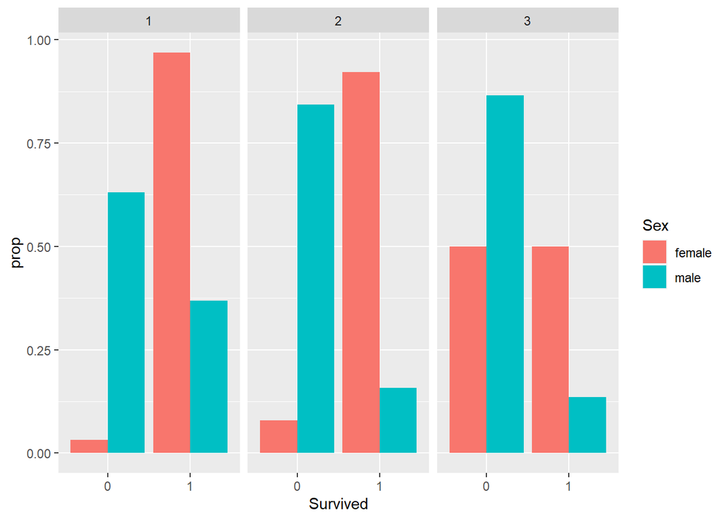

```r
ggplot(titanic, aes(x = Survived,
                    fill = Sex,
                    y= after_stat(prop),
                    group = Sex) ) +
  geom_bar(position = "dodge") +
  facet_wrap(~ Pclass)
```

Spazio per la tua analisi del grafico:

### Esercizio 6

In che modo l’età è correlata con la sopravvivenza? Quale ti aspetti che sia la sopravvivenza dei bambini (tra i 5 e i 15 anni) ?

Quali fasce di età sembrano avere una maggiore sopravvivenza? Quali una peggiore sopravvivenza?

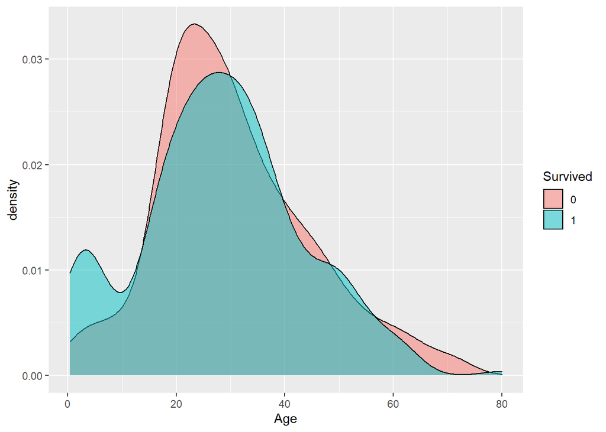

```r
ggplot(titanic, aes(x = Age,
                    fill = Survived)) +
  geom_density(alpha = 0.5)
```

Suggerimento: prova a usare la geometria geom_density(). Ti ricordi come si imposta la trasparenza dei grafici nelle estetiche?

Quali sono le possibili spiegazioni per il fenomeno?

Domanda: dovrebbe averti dato la notifica: “Removed 177 rows containing non-finite values (stat_density).”, cosa significa secondo te?

Commento libero:

### Esercizio 7

Essere parte di una famiglia aumentava le tue possibilità di sopravvivenza rispetto all’essersi imbarcati da soli?

Prima di fare il grafico creiamo la nuova variabile Family che contenga il numero di membri della famiglia presenti a bordo del passeggero, sommando `SibSp` e `Parch`

```r
titanic <- titanic %>%
  mutate( Family = SibSp + Parch )
```

Ora provate a costruire il grafico:

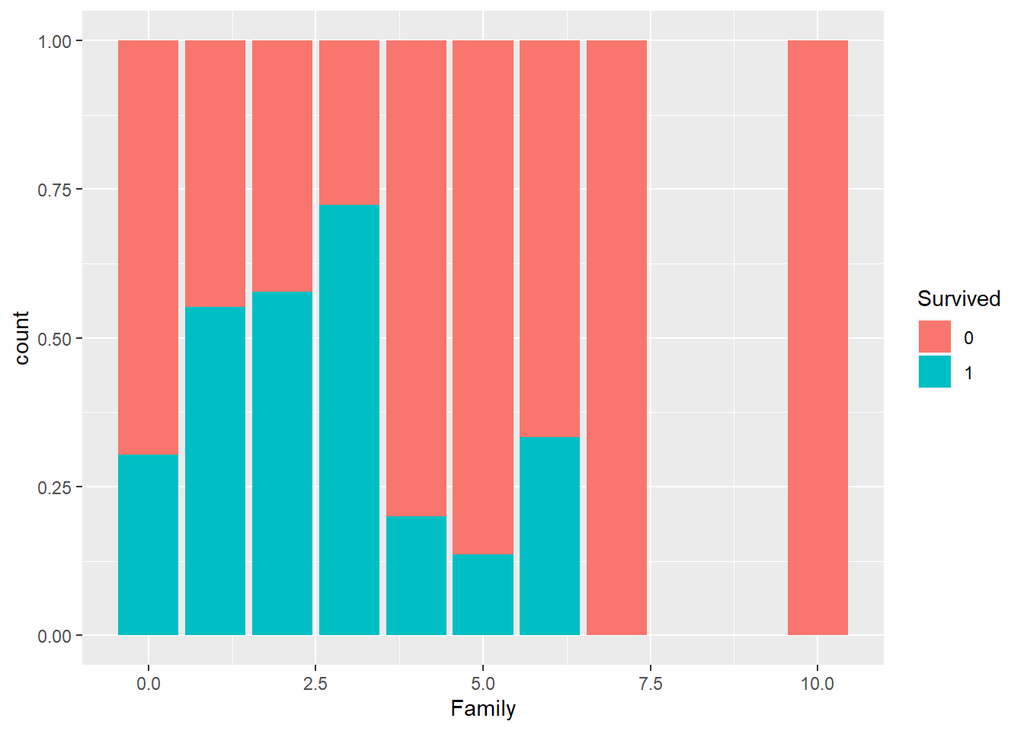

```r
ggplot(titanic, aes(x=Family, fill= Survived)) +
  geom_bar(position = "fill")
```

Suggerimento: quale `position = " "` potrebbe aiutare a comparare più comodamente le varie percentuali?

Spazio per la tua analisi del grafico: - la sopravvivenza aumenta con il crescere dei membri a bordo? Fino a quando? - quale potrebbe essere una criticità di questo grafico? Come viene rappresentata la nostra confidenza che la stima della percentuale di sopravvivenza sia attendibile?

### Esercizio 8

Il luogo d’imbarco ha avuto un impatto sulla probabilità di sopravvivenza?

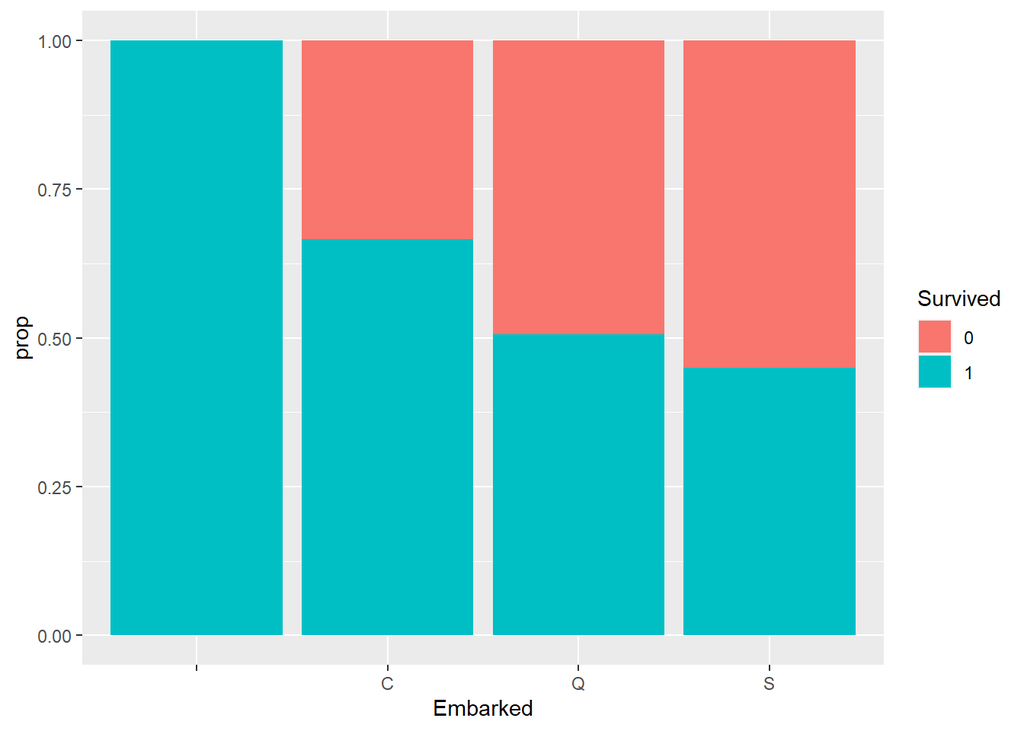

```r
ggplot(titanic, aes(x= Embarked,
                    fill = Survived,
                    y = after_stat(prop),
                    group = Survived)) +
  geom_bar(position = "fill")
```

Spazio per la tua analisi del grafico:

### Esercizio 9

Il costo pagato (o “ticket fare”) per i biglietti è legato alla classe d’imbarco?

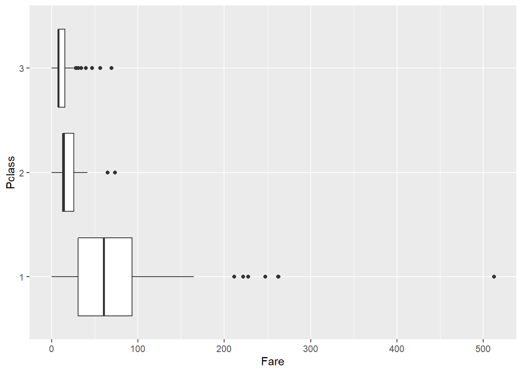

```r
ggplot(titanic, aes(y=Pclass,
                    x=Fare))+
  geom_boxplot()
```

Suggerimento: Un boxplot potrebbe aiutarti nella visualizzazione

Spazio per la tua analisi del grafico:

### Esercizio 10

Il costo pagato per i biglietti è correlato con la sopravvivenza?

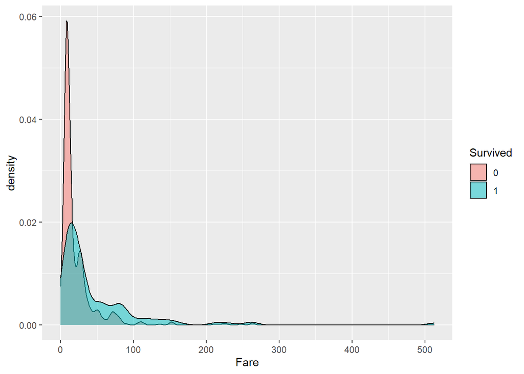

```r
ggplot(titanic, aes(x=Fare,
                    fill = Survived)) +
  geom_density(alpha=0.5)
```

Suggerimento: Prova a utilizzare geom_density

Spazio per la tua analisi del grafico:

### ESERCIZI LIBERI

Siete liberi di sperimentare altre visualizzazioni nel dataset, vi ricordiamo che per creare altre zone eseguibili di codice basta premerete contemporaneamente i tasti “ctrl+alt+i”

Quando hai terminato premi su `knit` (il gomitolo) per produrre automaticamente un report condivisibile in html del tuo lavoro.